# tutorial

Jakub Wiśniewski

# 1 Objects and Structure

## 1.1 Why?

Let’s say you are building court system that predicts if someone will become recidivist in the futre. First you gather information then you build a model and predict outcomes. You get accuracy score of 90%. It is preety good, but it appears that the model is more likely to say that African Americans will become recidivists. Model was trained on data that was discriminating certain ethnic groups. So now we have some options. First one is to change the data, and the second one is to tune model, and check if it behaves as we would like it to be. We will choose the second option.

## 1.2 Data

We will use modified ProPublica’s compass data to represent our problem.

```r
data("compas")

head(compas)
```

|  | Two_yr_Recidivism | Number_of_Priors | Age_Above_FourtyFive | Age_Below_TwentyFive | Sex | Misdemeanor | Ethnicity |
| --- | --- | --- | --- | --- | --- | --- | --- |
| 4 | 0 | -0.6843578 | no | no | Male | yes | Other |
| 5 | 1 | 2.2668817 | no | no | Male | no | Caucasian |
| 7 | 0 | -0.6843578 | no | no | Female | yes | Caucasian |
| 11 | 0 | -0.6843578 | no | no | Male | no | African_American |
| 14 | 0 | -0.6843578 | no | no | Male | yes | Hispanic |
| 24 | 0 | -0.6843578 | no | no | Male | yes | Other |

We train and explain our model with `DALEX`

```r
# Train
rf_compas <- ranger(Two_yr_Recidivism ~., data = compas, probability = TRUE) # Wszystko

# numeric target values
y_numeric <- as.numeric(compas$Two_yr_Recidivism)-1

# explainer
rf_explainer <- explain(rf_compas, data = compas[,-1], y = y_numeric)
```

```
#> Preparation of a new explainer is initiated
#>   -> model label       :  ranger  (  default  )
#>   -> data              :  6172  rows  6  cols
#>   -> target variable   :  6172  values
#>   -> model_info        :  package ranger , ver. 0.12.1 , task classification (  default  )
#>   -> predict function  :  yhat.ranger  will be used (  default  )
#>   -> predicted values  :  numerical, min =  0.1438169 , mean =  0.4549846 , max =  0.8486673
#>   -> residual function :  difference between y and yhat (  default  )
#>   -> residuals         :  numerical, min =  -0.7879805 , mean =  0.0001353191 , max =  0.83615
#>   A new explainer has been created!
```

Than we create `fairness_object` with `create_fairness_object()`

```r
fobject <- create_fairness_object(rf_explainer,
                                  data = compas, # it is important to specify all data if explainer doesn't have it
                                  outcome = "Two_yr_Recidivism", # target variable
                                  group  = "Ethnicity",          # protected group
                                  base   = "Caucasian")          # to what subgroupwe want to compare
                                                                 # cutoff - optional, deafult = 0.5
```

And we plot!

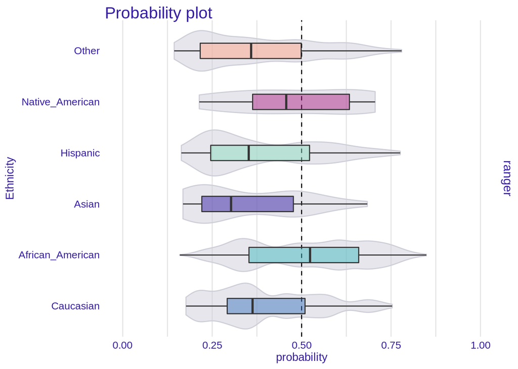

```r
plot(fobject)
```

As we can see it is more likely that model will categorise African Americans as future recidivists than for example Asians. But mabey some groups are statisticaly more likely to go do crimes in the future. It is possible, but there are more ways that the model can discriminate people.

## 1.3 Fairness Object

To really see what `fairness_object` is about, we need to make some more models and explainers.

```r
set.seed(123)

rf_compas_1 <- ranger(Two_yr_Recidivism ~Number_of_Priors+Age_Below_TwentyFive, data = compas, probability = TRUE)
lr_compas_1 <- glm(Two_yr_Recidivism~., data=compas, family=binomial(link="logit"))
rf_compas_2 <- ranger(Two_yr_Recidivism ~., data = compas, probability = TRUE)
rf_compas_3 <- ranger(Two_yr_Recidivism ~ Age_Above_FourtyFive+Misdemeanor, data = compas, probability = TRUE)
rf_compas_4 <- ranger(Two_yr_Recidivism ~., data = compas, probability = TRUE)
df <- compas
df$Two_yr_Recidivism <- as.numeric(compas$Two_yr_Recidivism)-1
gbm_compas_1<- gbm(Two_yr_Recidivism~., data = df)

explainer_1 <- explain(rf_compas_1,  data = compas[,-1], y = y_numeric)
explainer_2 <- explain(lr_compas_1,  data = compas[,-1], y = y_numeric)
explainer_3 <- explain(rf_compas_2,  data = compas[,-1], y = y_numeric, label = "ranger_2")
explainer_4 <- explain(rf_compas_3,  data = compas[,-1], y = y_numeric, label = "ranger_3")
explainer_5 <- explain(gbm_compas_1, data = compas[,-1], y = y_numeric)
explainer_6 <- explain(rf_compas_4,  data = compas[,-1], y = y_numeric, label = "ranger_4")
```

Now we create one object with all explainers

```r
fobject <- create_fairness_object(explainer_1,explainer_2,explainer_3,explainer_4,explainer_5,explainer_6,
                                  data = compas,
                                  outcome = "Two_yr_Recidivism",
                                  group  = "Ethnicity",
                                  base   = "Caucasian")
```

As we can see there is some parameters in fobject such as:  
1. DALEX Explainer or list of explainers  
2. data - if first explainer was not provided with whole data frame, we should do it here  
3. outcome - target variable, what we want to predict  
4. group - protected group/ sensitive variable which can be unfairly treated  
5. base - to what subgroup we want to compare metric scores with. If not provided gets first subgroup in data.

What consists of fairness object?

```r
print(fobject)
```

```
#> Fairness Matrics:
#>   equal_odds pred_rate_parity acc_parity fnr_parity fpr_parity npv_parity
#> 1  0.6473150        0.4587633  0.4380118  1.1594203  1.9767689  0.5303997
#> 2  0.5333551        0.1655958  0.2037848  1.8593806  2.7201109  1.4264519
#> 3  0.4304766        0.5038655  0.4692567  1.2599355  2.3974233  0.6699489
#> 4  0.5965355        0.7206892  0.3320299  0.8397114  0.9987922  0.7617980
#> 5  0.4364146        0.3839622  0.3732516  1.7778982  1.9837027  1.0073363
#> 6  0.4377685        0.4742514  0.4621125  1.4448375  2.1346233  0.5790816
#>   spec_parity mcc_parity model labels
#> 1   1.1537921   1.976073       ranger
#> 2   2.8289962   2.575408           lm
#> 3   1.6656774   1.966867     ranger_2
#> 4   0.7290221   2.208520     ranger_3
#> 5   2.2816360   2.563100          gbm
#> 6   1.7054448   1.859230     ranger_4
#> Models explained:
#> [1] "ranger"
#> [1] "lm"
#> [1] "ranger_2"
#> [1] "ranger_3"
#> [1] "gbm"
#> [1] "ranger_4"
#>
#> Data:
#>   Two_yr_Recidivism Number_of_Priors Age_Above_FourtyFive Age_Below_TwentyFive
#> 4                 0       -0.6843578                   no                   no
#> 5                 1        2.2668817                   no                   no
#>    Sex Misdemeanor Ethnicity probabilities
#> 4 Male         yes     Other     0.2209553
#> 5 Male          no Caucasian     0.6800501
```

Fairness object gets metrics based on confussion matrix and checks them over the groups.

```r
# for the first model
fobject$groups_data[[1]]$fpr_parity
```

```
#>        Caucasian African_American            Asian         Hispanic
#>        1.0000000        1.5690392        0.5287562        0.7854233
#>  Native_American            Other
#>        1.3512658        0.6293567
```

If we were going only to take score from certain metric (Let’s say fpr and 0.3) we wouldn’t know if it is good or bad. But we are aiming for **equal treatment over all groups** so if this metric score would be the same in all groups it would be very good. But the metrics wouldn’t be comparable between each others (fpr - 0.3 in all groups and acc_parity - 0.9 in all groups, both are good in terms of parity). That is wy we use **base** - to set benchmark. And for example Caucasian in fpr had score of 0.3 and African American 0.6. After setting `base = Caucasian` Caucasian would have score 1, and African American 2, because is two times higher score in fpr.

*Note: When dealing with aggregating plots we use formula sum(abs(1-score)) to represent aggregated score in metrics. In short is how much it differs from ideal scores.*

# 2 Choosing best model

We now have a few models in our `fairness_object`

Let’s see how they perform in diffrent metrics.

## 2.1 Stacked Barplot

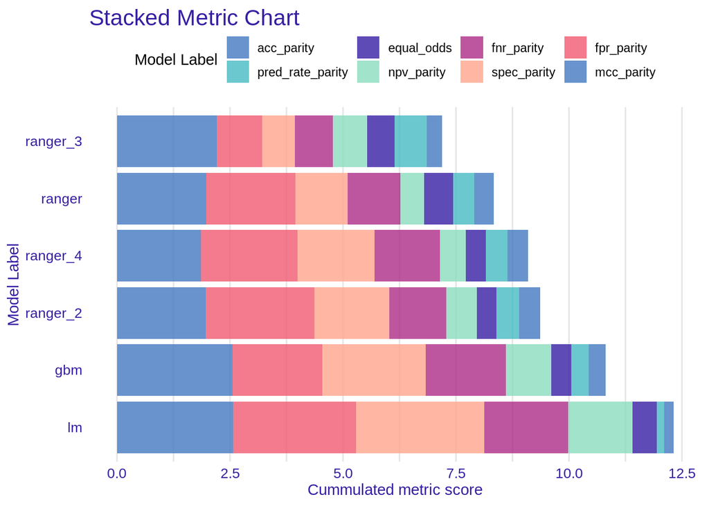

```r
plot_stacked_barplot(fobject)
```

At first we see that lm is the worst overall model. It does not give us information if plots are similar to each other.

## 2.2 Plot fairness PCA

With this task we should use `PCA`. We call `create_fairness_pca()` to create fairness pca object.

```r
fair_pca <- create_fairness_pca(fobject)
print(fair_pca)
```

```
#> Fairness PCA :
#>             PC1        PC2        PC3         PC4         PC5           PC6
#> [1,] -1.5811634  0.2076860 -1.3470271 -0.45565793 -0.07081256  1.387779e-16
#> [2,]  3.7397492  0.8728383 -0.5693240  0.32616780  0.04948430 -4.440892e-16
#> [3,] -0.6535961 -1.4668685  0.1474837  0.43006349 -0.33332381  1.859624e-15
#> [4,] -2.3834603  2.0274052  0.6248106  0.24714095  0.04051270 -1.595946e-16
#> [5,]  1.6009839 -0.1067351  1.0378585 -0.63087995 -0.08235603  1.110223e-16
#> [6,] -0.7225132 -1.5343259  0.1061982  0.08316565  0.39649540 -2.525757e-15
#>
#> Created with:
#> [1] "ranger"   "lm"       "ranger_2" "ranger_3" "gbm"      "ranger_4"
#>
#> First two components explained 88 % of variance.
```

Let’s plot!

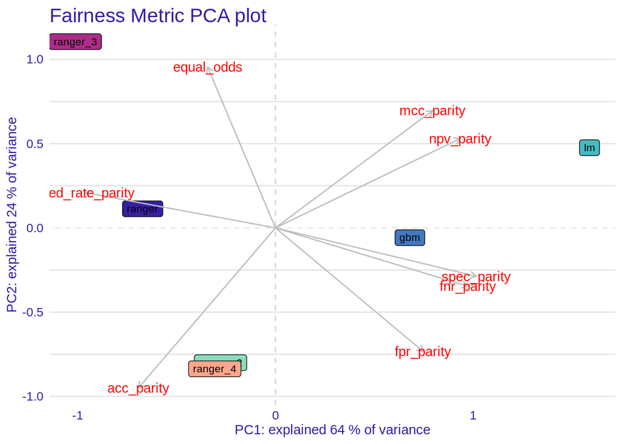

```r
plot(fair_pca)
```

It is done with loadings plot, which can be customised.

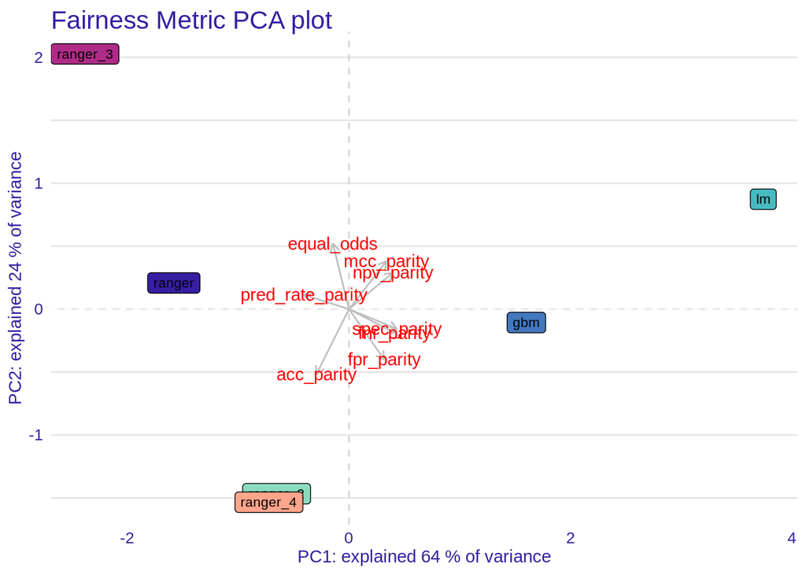

```r
plot(fair_pca, scale = 0) # deafult = 0.5
```

## 2.3 Plot Heatmap

Another way to deal with grouped data is using heatmap.

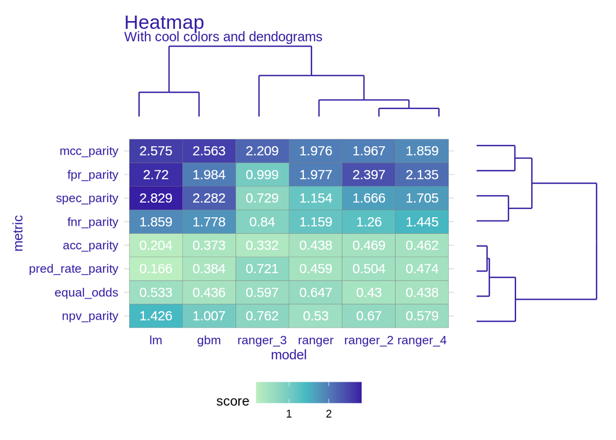

```r
plot_heatmap(fobject, subtitle = "With cool colors and dendograms")
```

For both models and metrics dendograms are created. This way through hierarchical clustering we can look on similarities between models/metrics. It should give similar but more detailed information than PCA

It can be normalised among metrics.

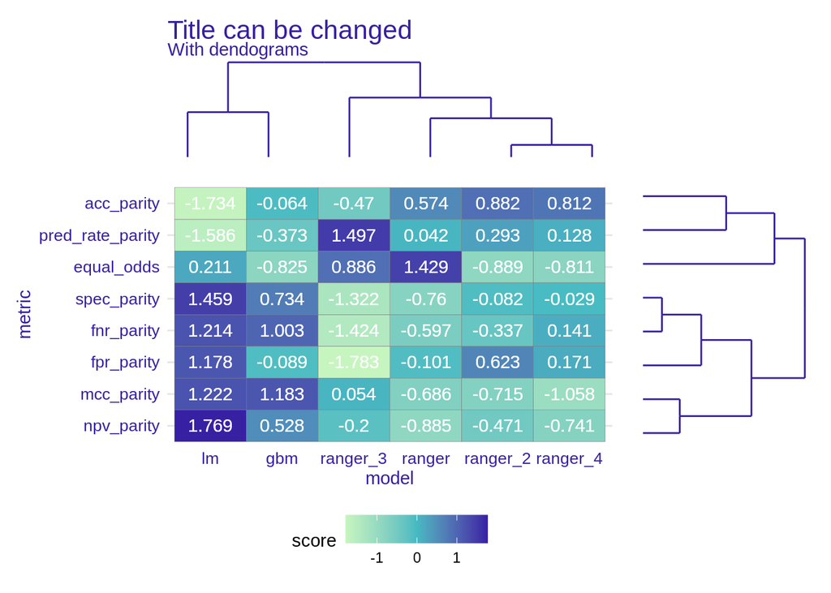

```r
plot_heatmap(fobject, scale = TRUE, title = "Title can be changed") # we can turn values off via text= FALSE
```

Sometimes we would like to know how good are models in performance metrics and in fairness metrics at the same time, to see the tradeoff between them.

```
#> Performace metric is NULL, setting deafult ( auc )
#>
#> Creating object with:
#> Fairness metric fpr_parity
#> Performance metric  auc
```

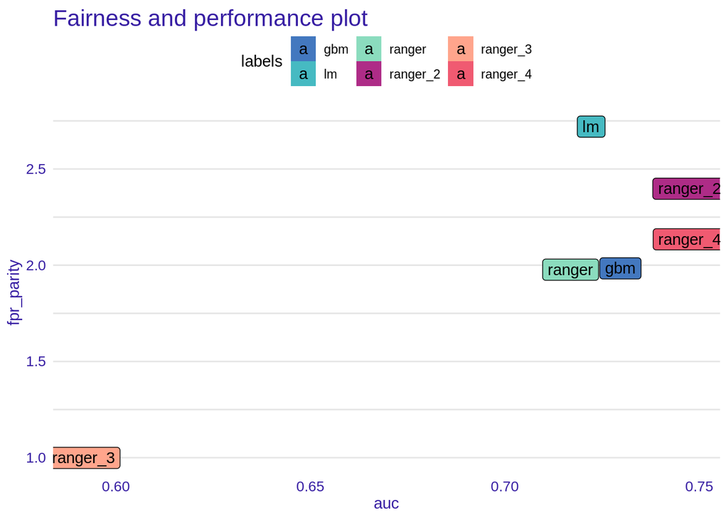

```r
plot_performance_with_fairness(fobject, fairness_metric = "fpr_parity")
```

We can add plots with help of `patchwork`

```r
library(patchwork)
library(ggplot2)

p1 <- plot_performance_with_fairness(fobject,  "equal_odds", "accuracy")
p2 <- plot_performance_with_fairness(fobject,  "fpr_parity", "auc")     + ggtitle(" ") + theme(legend.position = "none")
p3 <- plot_performance_with_fairness(fobject,  "npv_parity", "recall")  + ggtitle(" ") + theme(legend.position = "none")
p4 <- plot_performance_with_fairness(fobject,  "pred_rate_parity", "f1")+ ggtitle(" ") + theme(legend.position = "none")
```

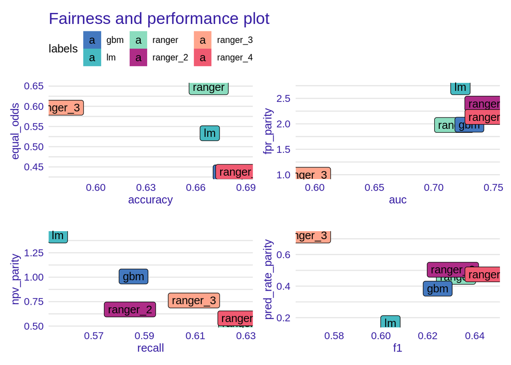

```r
(p1 + p2)/(p3+p4)
```

## 2.4 Back to detail

When we have narrowed down our search for the best model we can use `two_models_plot` to check once again metrics within groups and decide which model to use.

```
#> Performace metric is NULL, setting deafult ( auc )
#>
#> Creating object with:
#> Fairness metric fpr_parity
#> Performance metric  auc
#> [1] "auc"
```

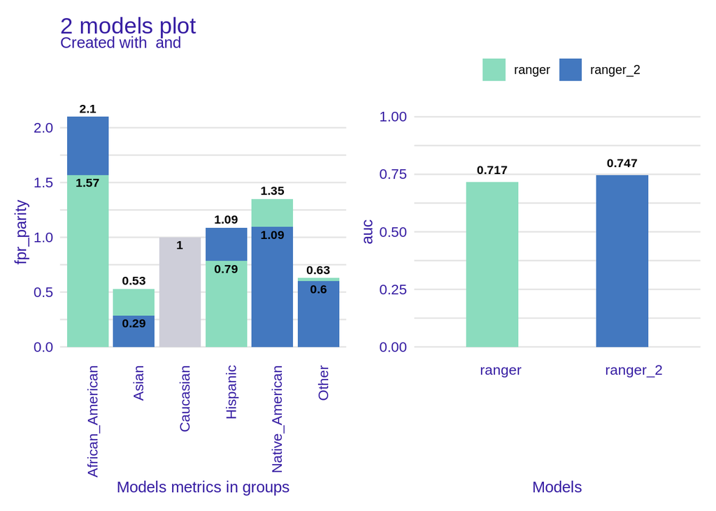

```r
fobject2 <- create_fairness_object(explainer_1,explainer_3,
                                   data = compas,
                                  outcome = "Two_yr_Recidivism",
                                  group  = "Ethnicity",
                                  base   = "Caucasian")

plot_two_models(fobject2, fairness_metric = "fpr_parity") # both fairness_metric and performance_metric have deafult values
```

We can also use simple `plot` when we have only few explainers.

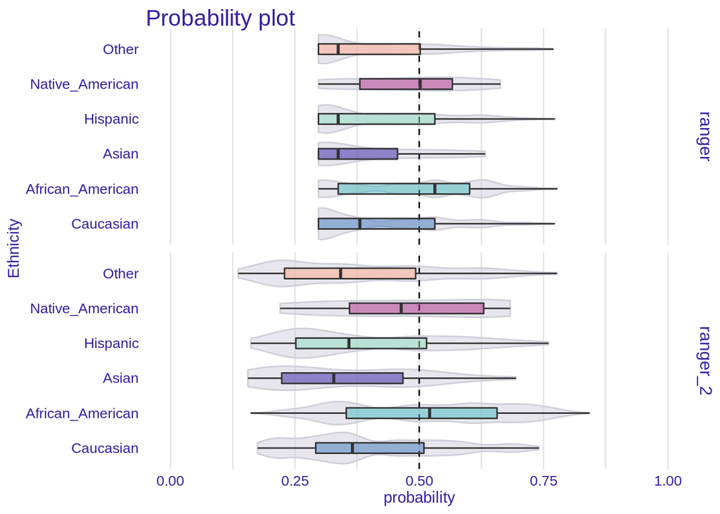

```r
plot(fobject2)
```

Of course the protected group can be changed.

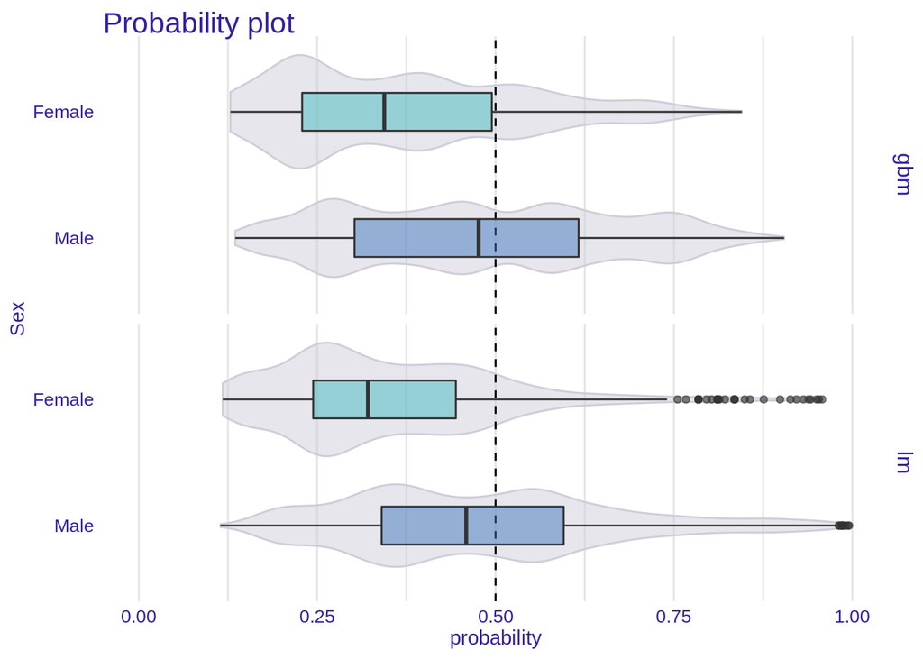

```r
fobject3 <- create_fairness_object(explainer_2,explainer_5,
                                   data = compas,
                                  outcome = "Two_yr_Recidivism",
                                  group  = "Sex",
                                  base = "Female")
plot(fobject3)
```